# 2. R and CF Metadata Conventions

## The CF Metadata Conventions

The CF Metadata Conventions (“CF” henceforth) are being developed by academics and practitioners in the climate and forecasting field, with the objective to facilitate interoperability between data producers and data consumers (whether human or computer systems).

Reading the CF documentation can be a daunting task because it is written as a standards document, and not as a guideline or tutorial for people who want to understand the concept and the structure but who are not looking for all of the low-level detail.

This vignette presents a view of CF from the perspective of R. The main elements of CF are introduced in terms that should be easily understood by anyone who has worked with matrices and arrays in R.

By definition, a CF-compliant data set is stored in a netCDF file. The CF elements and their relationship to the building blocks of the netCDF file are given in the figure below:

[figure not shown]

*Figure 1: Elements of a netCDF file and the CF constructs built on them. Source: CF Conventions, Appendix I.*

If you’ve worked with netCDF data in R before, probably using package `ncdf4` (but what follows is equally true when you use package `RNetCDF`), you should be familiar with the yellow boxes in the above figure, especially “NC::Variable” (the specific notation used in the figure is not important here), corresponding to the `ncvar4` class in `ncdf4`. CF, however, recognizes 11 different objects that are each based on an “NC::Variable”. This ranges from axes, or *generic coordinate variables* in the white box in the figure, to *grid mapping variables* (that define the coordinate reference system of your data) to the actual data array in a *data variable*. This is the source of all those surprising “variables” that you see when you do `names(nc$var)`:

```
library(ncdf4)

fn <- system.file("extdata", "tasmax_NAM-44_day_20410701-vncdfCF.nc", package = "ncdfCF")
nc <- nc_open(fn)

# The "variables"
names(nc$var)
#> [1] "time_bnds"         "lon"               "lat"
#> [4] "Lambert_Conformal" "height"            "tasmax"

# The dimensions
names(nc$dim)
#> [1] "time" "bnds" "x"    "y"
```

So which of these variables is the one that holds your data? And how do you tell it apart from the other “variables”? And why are there `x` and `y` dimensions and `lon` and `lat` “variables”?

### Enter the attributes

You may not be as familiar with the attributes in the netCDF file, the “NC::Attribute” object in the above figure, as `ncdf4` does not make these as easily accessible as the other information in the file. That is a shame because attributes are the thing that makes netCDF stand apart from pretty much any other gridded data format. CF is actually all about attributes, with some of them organized in “NC::Variable” objects that do not hold any other data! (Such as the *grid mapping variables* mentioned above.) Put the other way around, you are not really using a CF-compliant netCDF data set unless you read the proper attributes. Even stronger: there are things in netCDF data sets that you cannot do unless you have inspect the attributes (such as determining the coordinate reference system, or calculating the parametric coordinates of a vertical axis).

Looking at the same netCDF file as above, but now using the `ncdfCF` package:

```r
library(ncdfCF)

fn <- system.file("extdata", "tasmax_NAM-44_day_20410701-vncdfCF.nc", package = "ncdfCF")
ds <- open_ncdf(fn)

# The data variable
names(ds)
```

```
#> [1] "tasmax"
```

```r
# The details of the data variable
tmax <- ds[["tasmax"]]
tmax$print(width = 25)
```

```
#> <Variable> tasmax
#> Long name: Daily Maximum Near-Surface Air Temperature
#>
#> Values: (not loaded)
#>
#> Coordinate reference system:
#>  name              grid_mapping
#>  Lambert_Conformal lambert_conformal_conic
#>
#> Axes:
#>  axis name   long_name                 length values
#>  X    x      x-coordinate in Cartes... 148    [0 ... 7350000]
#>  Y    y      y-coordinate in Cartes... 140    [0 ... 6950000]
#>  T    time                             1-U    [2041-07-01T12:00:00]
#>  Z    height                           1      [2]
#>  unit
#>  m
#>  m
#>  days since 1949-12-1 0...
#>  m
#>
#> Auxiliary longitude-latitude grid:
#>  axis name extent                 unit
#>  X    lon  [-174.382 ... -19.618] degrees_east
#>  Y    lat  [10.154 ... 76.459]    degrees_north
#>
#> Attributes:
#>  name          type     length value
#>  standard_name NC_CHAR  15     air_temperature
#>  long_name     NC_CHAR  42     Daily Maximum Near-Sur...
#>  units         NC_CHAR   1     K
#>  grid_mapping  NC_CHAR  17     Lambert_Conformal
#>  coordinates   NC_CHAR  14     height lat lon
#>  _FillValue    NC_FLOAT  1     1.00000002004088e+20
#>  missing_value NC_FLOAT  1     1.00000002004088e+20
#>  original_name NC_CHAR  11     TEMP at 2 M
#>  cell_methods  NC_CHAR  13     time: maximum
#>  FieldType     NC_INT    1     104
#>  MemoryOrder   NC_CHAR   3     XY
```

```r
# The "time" axis
ds[["time"]]
```

```
#> <Time axis> [0] time
#> Length     : 1 (unlimited)
#> Axis       : T
#> Calendar   : 365_day
#> Range      : 2041-07-01T12:00:00 (days)
#> Bounds     : 2041-07-01 ... 2041-07-02
#>
#> Attributes:
#>  name          type      length value
#>  standard_name NC_CHAR    4     time
#>  long_name     NC_CHAR    4     time
#>  bounds        NC_CHAR    9     time_bnds
#>  units         NC_CHAR   29     days since 1949-12-1 00:00:00
#>  calendar      NC_CHAR    7     365_day
#>  axis          NC_CHAR    1     T
#>  actual_range  NC_DOUBLE  2     33427.5, 33427.5
```

```r
# Parameters in the grid mapping variable
ds[["Lambert_Conformal"]]
```

```
#> <Grid mapping> Lambert_Conformal
#> Grid mapping name: lambert_conformal_conic
#>
#> Attributes:
#>  name                          type      length value
#>  grid_mapping_name             NC_CHAR   23     lambert_conformal_conic
#>  longitude_of_central_meridian NC_DOUBLE  1     -97
#>  latitude_of_projection_origin NC_DOUBLE  1     46.0000038146973
#>  standard_parallel             NC_DOUBLE  2     35, 60
#>  false_easting                 NC_DOUBLE  1     3675000
#>  false_northing                NC_DOUBLE  1     3475000
```

Ok, that’s a lot more information. Let’s focus on a few important things:

1. There is only one *data variable*, called “tasmax”. If we examine it’s details we can see that it’s coordinate space uses four axes `x`, `y`, `time` and `height`. That is not all clear from the `ncdf4` output which lists the first three dimensions and excludes `height`, but includes `bnds` instead.
2. The data set has a *grid mapping variable* called `Lambert_Conformal` that, by definition, applies to the `X` and `Y` axes of the *data variable* `tasmax`. As suggested by CF, the data set also includes two *auxilliary coordinate variables* `lat` and `lon`, each a matrix with the same dimension as the length of the `Y` and `X` axes of the *data variable* they are associated with, where each cell gives the latitude and longitude, respectively, of the corresponding cell in the *data variable* (whose axes have coordinates in the Lambert Conformal coordinate reference system). You can identify these two aspects by looking at the attributes of `tasmax`: attribute `grid_mapping` points to the *grid mapping variable* `Lambert_Conformal`, attribute `coordinates` lists both the *scalar coordinate variable* `height` and the *auxiliary coordinate variables* `lat` and `lon`.
3. The `time` axis has an attribute `bounds` which points to `time_bnds`, a *boundary variable* that indicates for each coordinate along the axis its lower and higher values. For the `time` axis there is just one coordinate at `2041-07-01 12:00:00` with range values `2041-07-01 ... 2041-07-02` (midnight to midnight). (It is the `time_bnds` *boundary variable* that uses the `bnds` dimension that `ncdf4` reports.) The `calendar` used by this axis is `365_day`, meaning that no year uses the leap day of 29 February. This is a so-called “model calendar” and the standard date-time functions will not work properly with this data; use the built-in time methods instead.

It should be obvious that correctly interpreting a netCDF file requires a package that not only provides easy access to the attributes of the file, but that also applies the CF conventions to put all the pieces together in such a way that the data set is presented to the user of the data - that would be you - as the data producers intended.

The issues arising from the pecularities of CF on top of the netCDF format are presented and discussed in the remainder of this document, seen from the perspective of the R user, with examples using the `ncdfCF` package. At the end of this vignette is a feature matrix that indicates the support for each CF element in package `ncdfCF`.

> Please note that I have nothing against `ncdf4` or `RNetCDF` packages. In fact, package `ncdfCF` is built on top of `RNetCDF`. My point is merely to demonstrate how CF-compliant netCDF files, of which there are *very* many out there on the internet, require you to look beyond the basic netCDF building blocks and use the attributes. If your netCDF files do not use the CF conventions, then by all means use `ncdf4` if you prefer. I would suggest, though, to read the next section to understand better how data structures in netCDF differ from R standard practices.

## Arrays in R versus netCDF files

In R, matrices and arrays are stored in column-major ordering, meaning that successive values go from the top-left down down the column, then across the columns to the bottom-right. This is easily seen when printing a matrix to the console:

```r
matrix(1:12, nrow = 3, ncol = 4)
```

```
#>      [,1] [,2] [,3] [,4]
#> [1,]    1    4    7   10
#> [2,]    2    5    8   11
#> [3,]    3    6    9   12
```

In netCDF files matrices and arrays are stored in row-major ordering, starting from the left, progressing to the end of the row and then to the next row. This can be performed in R with the `byrow` argument of the `matrix()` function, with data starting from the top-left:

```r
matrix(1:12, nrow = 3, ncol = 4, byrow = TRUE)
```

```
#>      [,1] [,2] [,3] [,4]
#> [1,]    1    2    3    4
#> [2,]    5    6    7    8
#> [3,]    9   10   11   12
```

CF-compliant data sets, however, are free to store the data in any possible organization of the axes, although the recommendation is to use the longitude - latitude - vertical - time - others ordering. But even when that recommendation is followed, the latitude coordinates in the row are often stored in ascending order from South to North, that is from the bottom-left working upwards. That looks like this:

```r
matrix(c(9, 5, 1, 10, 6, 2, 11, 7, 3, 12, 8, 4), nrow = 3, ncol = 4)
```

```
#>      [,1] [,2] [,3] [,4]
#> [1,]    9   10   11   12
#> [2,]    5    6    7    8
#> [3,]    1    2    3    4
```

This is the cause of lots of headaches and “patches” involving `t()` and `rev()` in *some* order and general exasperation (*“why does it have to be so complicated?”*).

The bottom line is that there is no guarantee that the data are stored in a particular ordering. So how can you make sure that you get the data from the netCDF file in a predictable format so that you can use your favourite analysis routines with peace of mind? The answer should be obvious: read the attributes of the netCDF file and apply them following CF guidelines.

Lucky for you package `ncdfCF` does all the dirty work behind the scene to give you easy access to either the raw array data, in the ordering found in the netCDF file, or an oriented array that follows the standard R array layout:

```r
# The raw data using the ordering in the netCDF file (or as modified by
# a processing method such as `summarise()`)
tmax_raw <- tmax$raw()
str(tmax_raw)
```

```
#>  num [1:148, 1:140, 1] 301 301 301 301 301 ...
#>  - attr(*, "dimnames")=List of 3
#>   ..$ x   : chr [1:148] "0" "50000" "1e+05" "150000" ...
#>   ..$ y   : chr [1:140] "0" "50000" "1e+05" "150000" ...
#>   ..$ time: chr "2041-07-01T12:00:00"
```

```r
# The same data but now in standard R ordering
tmax_R <- tmax$array()
str(tmax_R)
```

```
#>  num [1:140, 1:148, 1] 277 277 277 277 277 ...
#>  - attr(*, "dimnames")=List of 3
#>   ..$ y   : chr [1:140] "6950000" "6900000" "6850000" "6800000" ...
#>   ..$ x   : chr [1:148] "0" "50000" "1e+05" "150000" ...
#>   ..$ time: chr "2041-07-01T12:00:00"
```

Note how in the `array()` version the `x` and `y` axes are reversed and the `y` values decrease, i.e. working from the top-left down to the bottom-right, just like a standard R array.

## ncdfCF data model in a nutshell

The netCDF file format is very flexible, as well as CF, and the `ncdfCF` package uses a layered structure to capture it all. This structure enables a full support of the features provided by the `netcdf` library and the CF Conventions.

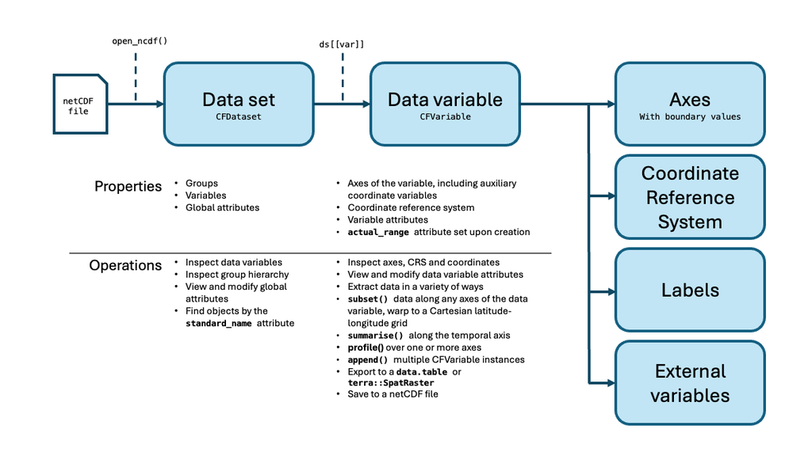

Figure 2: Core ncdfCF data model

Each of the building blocks may have other objects associated with it, such as axes for `CFVariable`. Package `ncdfCF` is built using the `R6` OOP framework and uses class hierarchies throughout. The crucial but humble “virtual” class `CFAxis` is not used directly, instead you’ll work with its seven descendant classes. `CFVariable` has several specialised sub-classes, such as `CFVariableL3b` for NASA level-3 binned data used for MODIS imagery, or `CFVerticalParametricTerm` which you will encounter when using *formula terms* for a parametric vertical axis.

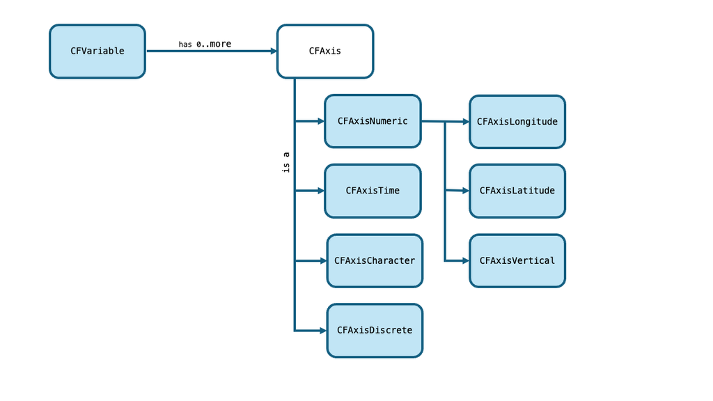

Figure 3: Condensed ncdfCF axis class hierarchy

## Feature matrix

This section provides an overview of how this package implements the various elements of the CF Conventions.

#### 2. NetCDF files and components

##### 2.1. Filename

Any filename extension is allowed.

##### 2.2. Data types

Any allowable data type can be read to and written from a netCDF file. In R, only the standard data types are used.

##### 2.3. Naming conventions

It is *required* that variable, dimension, attribute and group names begin with a letter and be composed of letters, digits, and underscores. The maximum length of a name is 255 characters.

Names of NC variables - thus the names of CF objects built on top of them as well - must be unique, disregarding the case of the name, *within the group* in which the NC variable is defined. Scoping at group level is not mentioned in the CF conventions and this is thus an extension of the conventions.

##### 2.4. Dimensions

Fully implemented. Scalar coordinate variables are supported in reading and writing, but internally represented as an axis with length 1.

##### 2.5. Variables

The `actual_range` attribute is determined when a `CFVariable` is created from a netCDF resource or its values modified in code. The attribute is also attached to all axes and their boundaries.

Upon saving a `CFVariable` to a netCDF file, data may be packed and the appropriate attributes will be written along with the data.

##### 2.6. Attributes

This package only interprets attributes that are defined by CF to have a special meaning that is relevant to reading, processing or writing data. Other attributes are read and presented to the user.

The attribute `Conventions` is written to file with value “CF-1.12”.

The attribute `history` is created in the group of the data variable or prepended with information on any processing that has been applied to the data.

Other global, group or data variable attributes are not written to file automatically; the user has to add to amend these attributes explicitly.

##### 2.7. Groups

Fully implemented.

#### 3. Description of the data

##### 3.1. Units

The package optionally uses the `units` package which provides access to the UDUNITS library to manage units or convert between them.

The `units` attribute is interpreted for axes and effectively required for the dimensions “that receive special treatment” (see sections 4.1 - 4.4) or they will not be recognized as such. Otherwise presence or contents of the attribute is not tested.

The `units_metadata` attribute is not managed by this package. It is the responsibility of the user to set the appropriate value.

Attributes `scale_factor` and `add_offset` are only used for packing data (section 8.1).

##### 3.2 Long name

Supported for all objects that have this attribute.

##### 3.3 Standard name

The standard names table can optionally (and automatically) be accessed through the `CF$standard_names` object. Management of the XML is automatic, including periodic checks to see if an update is available.

The `standard_name` attribute is read but not checked against the standard name table. Objects with a `standard_name` attribute can be identified with the `CFDataset$objects_by_standard_name()` method, either for presence of the attribute or using a specific standard name.

##### 3.4. Ancillary data

Not supported.

##### 3.5. Flags

Not implemented directly but using the `flag_values` and `flag_meanings` attributes is trivial on the user side.

#### 4. Coordinate types

When opening a netCDF resource, axes are scanned for using the `units` or `axis` attribute, then the `standard_name`, and finally, as an extension to CF, by its `name` attribute.

Upon writing, the `axis` attribute is added, if defined and not already present.

##### 4.1. Latitude coordinate

Fully implemented.

##### 4.2. Longitude coordinate

Fully implemented.

##### 4.3. Vertical (heigth or depth) coordinate

Fully implemented for dimensional vertical axes. If the `units` library is available, a unit of pressure will be identified.

Parametric vertical coordinates are partially supported. Of the nine available formulations, the “Ocean s-coordinate, generic form 1” and “Ocean s-coordinate, generic form 2” are implemented. Other formulations will be implemented as sample data is made available for testing the code.

##### 4.4. Time coordinate

The time coordinate is managed by the CFtime package. All defined calendars, including the recently added `utc` and `tai` calendars, are supported, with some restrictions. Leap seconds are fully supported in notation and arithmetic when using the `utc` calendar.

The deprecated `gregorian` calendar is replaced by the equivalent `standard` calendar.

Time coordinates with an explicitly defined calendar is not supported.

##### 4.5. Discrete axis

Fully supported.

#### 5. Coordinate systems and domain

The `coordinates` attribute is interpreted, both for *coordinate variables* and *auxiliary coordinate variables*.

In `ncdfCF`, *auxiliary coordinate variables* will have axis orientations attached to them for ease-of-use and identification. This orientation will not be written to file as an `axis` attribute.

##### 5.1. Independent latitude, longitude, vertical, and time axes

Fully supported.

##### 5.2. Two-dimensional latitude, longitude, coordinate variables

Fully supported.

##### 5.3. Reduced horizontal grid

Not supported. But do note that one significant data collection of netCDF files using a reduced horizontal grid, MODIS level-3 binned format, uses a different format than the CF arrangement. `ncdfCF` does read this format without problem (extending CF by also supporting netCDF user-defined types).

##### 5.6. Horizontal coordinate reference systems, grid mappings, and projections

The simple `grid_mapping` format is fully supported. The extended, second format is not supported. The `standard_name` on coordinate variables is not used; instead use is made of the axis orientation (either through the `axis` attribute or through another supported mechanism; see section 4.).

`ncdfCF` uses OGC WKT2 strings to report on coordinate reference systems, rather than the stock-old and obsolete PROJ format as is suggested by CF.

The `crs_wkt` attribute is used when found.

##### 5.7. Scalar coordinate variables

Fully supported but internally represented as a regular axis of length 1.

##### 5.8. Domain variables

Not implemented.

##### 5.9. Mesh topology variables

Not implemented.

#### 6. Labels and alternative coordinates

##### 6.1. Labels

Generic labels are supported. This includes multiple sets of labels per axis. Labels can be used for display as well as in selection.

Geographic regions are also supported but not referenced against the list of *standardized region names*, as that list is severely restrictive, and neither is the `standard_name` attribute referenced in this context.

Taxon names and identifiers and their specific attributes are not specifically interpreted.

##### 6.2. Alternative coordinates

These are not specifically supported but they will be read correctly.

#### 7. Data representative of cells

##### 7.1. Cell boundaries

Fully supported for 1D and 2D coordinate variables. More strictly than the conventions, the coordinate value must fall on or between its two boundary values (which the conventions merely recommend).

Higher dimension boundaries on coordinate variables are not yet supported.

##### 7.2. Cell measures

Fully supported.

External variables can be linked to the `CFCellMeasure` instances that are created upon reading a netCDF resource and will then automatically be available to any referring data variables.

##### 7.3. Cell methods

The `cell_methods` attribute is read, as all other attributes are, but it is not parsed or interpreted.

Interactive users and packages built on top of `ncdfCF` should update the attribute after applying an operation to any data variable as the package does not have enough information to do so programmatically. A case in point is the `CFVariable::summarise()` method: the function to apply in summarising is user-supplied and this package has no knowledge of what that function does or results in: apart from built-in functions like `mean()` or `max()`, users can supply a custom-made function with multiple results and thus multiple resulting `CFVariable` instances that each need a specific update to the `cell_methods` attribute copied from the data variable being summarised.

##### 7.4. Climatological statistics

Climatological time series and their `climatology` bounds can be read from file.

Climatological statistics are generated when using the `CFVariable::summarise()` method and written to file, including their bounds.

The corresponding `cell_methods` are not yet supported.

##### 7.5. Geometries

Not implemented.

#### 8. Reduction of dataset size

##### 8.1. Packed data

Fully supported on reading and writing.

##### 8.2. Lossless compression by gathering

Not implemented.

##### 8.3. Lossy compression by coordinate subsampling

Not implemented.

##### 8.4. Lossy compression via quantization

Not implemented.

#### 9. Discrete sampling geometries

Not implemented.